# A Look at the Spanish-speaking Population in Texas

```r
library(tidyverse)
library(ggplot2)
library(waffle)
```

# Introduction

I am analyzing data on the non-English speaking population in Texas. My focus is mostly on the Spanish-speaking population, because it is the largest language-speaking group in Texas. I am comparing the Spanish-speaking population with people speaking other languages. I am comparing the groups in terms of poverty and education levels. All of my data are from the Census Bureau’s American Community Survey 1-year and 5-year estimates.

# Poverty Levels

Importing data

I have imported and cleaned this dataset in another notebook (01_import.Rmd) and will import the exported .rds file. The source of this dataset is data.census.gov. These are based on American Community Survey 1-year estimates.

```r
tx_poverty_language <- read_rds("data-out/above_below-1.rds")
tx_poverty_language
```

| year | total | moe_total | at_or_above_poverty_level | moe_at_or_above_poverty_level | languages | estimate_above | moe_above | below_poverty_level | moe_below_poverty_level | estimate_below | moe_below |
| --- | --- | --- | --- | --- | --- | --- | --- | --- | --- | --- | --- |
| 2010 | 22748636 | 6857 | 18883710 | 45231 | only_english | 12870847 | 41094 | 3864926 | 44825 | 1903850 | 33080 |
| 2010 | 22748636 | 6857 | 18883710 | 45231 | spanish | 4975363 | 42642 | 3864926 | 44825 | 1794164 | 38517 |
| 2010 | 22748636 | 6857 | 18883710 | 45231 | other_indo_european_languages | 403663 | 16285 | 3864926 | 44825 | 63414 | 8136 |
| 2010 | 22748636 | 6857 | 18883710 | 45231 | asian_and_pacific_island_languages | 519484 | 15075 | 3864926 | 44825 | 73440 | 7213 |
| 2010 | 22748636 | 6857 | 18883710 | 45231 | other_languages | 114353 | 8731 | 3864926 | 44825 | 30058 | 5261 |
| 2011 | 23140955 | 8434 | 19092665 | 54542 | only_english | 13075340 | 48327 | 4048290 | 54867 | 1996811 | 40884 |
| 2011 | 23140955 | 8434 | 19092665 | 54542 | spanish | 4970865 | 46535 | 4048290 | 54867 | 1882565 | 40767 |
| 2011 | 23140955 | 8434 | 19092665 | 54542 | other_indo_european_languages | 410606 | 18010 | 4048290 | 54867 | 63254 | 8178 |
| 2011 | 23140955 | 8434 | 19092665 | 54542 | asian_and_pacific_island_languages | 515580 | 17315 | 4048290 | 54867 | 74235 | 7695 |
| 2011 | 23140955 | 8434 | 19092665 | 54542 | other_languages | 120274 | 11798 | 4048290 | 54867 | 31425 | 5814 |

[output cut: 30 more lines]

The two main questions I had for this data are:

- What is the percentage of people above and below poverty for each language group? (visualize this.. pie chart? waffle chart?) probably only for 2017
- Is there a larger share of people below poverty within a certain language group?

In order to answer these questions, I have to create two new columns for the percentage of people below and at/above poverty level for each language groups.

```r
tx_poverty_language <- tx_poverty_language %>%
  mutate(
    pct_below = estimate_below/(estimate_below+estimate_above)*100, #for percentage of people below poverty
    pct_above = estimate_above/(estimate_below+estimate_above)*100 #for percentage of people at or above poverty
  )
```

The first thing I wanted to know was what are the percentages of people above/below poverty for each language.

I tried to visualize the share of the population that is below or above poverty for each language groups. I’m using waffle charts for this, with the waffle package. I’m doing this for the year 2017 only, because it is the most recent.

First, I need to select the columns that I need, which are year, languages, and the two percentage column (below and at/above poverty level.)

```r
poverty_2017_waffle <- tx_poverty_language %>%
  select (year, languages, pct_below, pct_above)
poverty_2017_waffle <- poverty_2017_waffle %>%
  filter(year == 2017) #filter for 2017, because I only want to create waffle charts for 2017
poverty_2017_waffle
```

| year | languages | pct_below | pct_above |
| --- | --- | --- | --- |
| 2017 | only_english | 11.22952 | 88.77048 |
| 2017 | spanish | 20.69205 | 79.30795 |
| 2017 | other_indo_european_languages | 11.26197 | 88.73803 |
| 2017 | asian_and_pacific_island_languages | 10.58880 | 89.41120 |
| 2017 | other_languages | 20.19951 | 79.80049 |

Then, I need to save each language to a separate dataset.

```r
english_17 <- poverty_2017_waffle %>%
  mutate(year = NULL) %>%
  filter(languages == "only_english") %>%
  select(pct_above, pct_below)
spanish_17 <- poverty_2017_waffle %>%
  mutate(year = NULL) %>%
  filter(languages == "spanish") %>%
  select(pct_above, pct_below)
european_17 <- poverty_2017_waffle %>%
  mutate(year = NULL) %>%
  filter(languages == "other_indo_european_languages") %>%
  select(pct_above, pct_below)
asian_17 <- poverty_2017_waffle %>%
  mutate(year = NULL) %>%
  filter(languages == "asian_and_pacific_island_languages") %>%
  select(pct_above, pct_below)
other_17 <- poverty_2017_waffle %>%
  mutate(year = NULL) %>%
  filter(languages == "other_languages") %>%
  select(pct_above, pct_below)
```

Finally, I can create the charts with waffle().

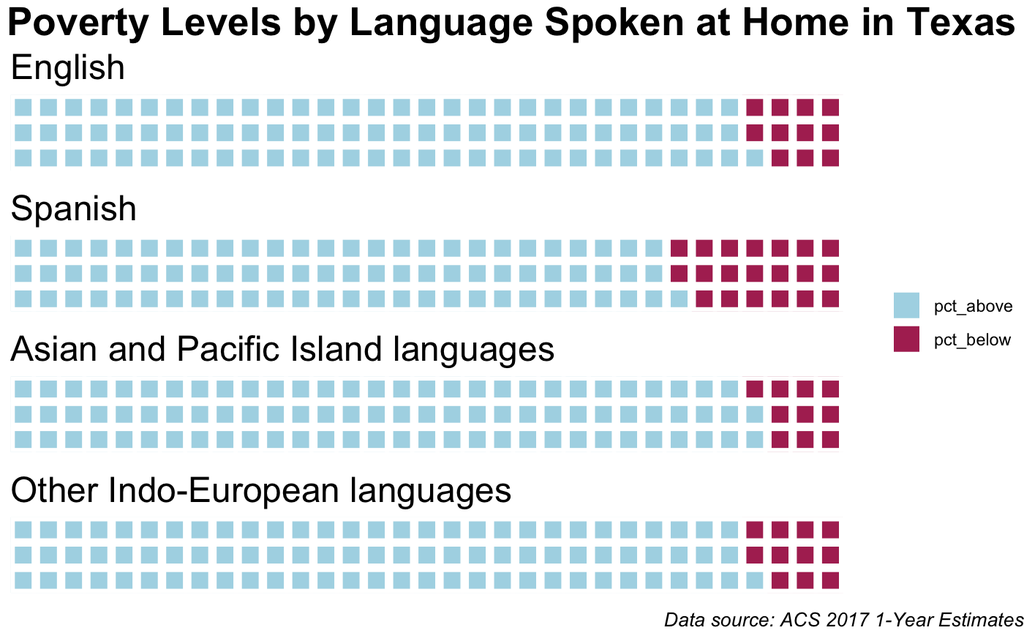

```r
english_2017 <- waffle(english_17, rows=3, title = "English", colors = c("light blue", "maroon", "white"))
spanish_2017 <- waffle(spanish_17, rows=3, title = "Spanish", colors = c("light blue", "maroon", "white"))
asian_2017 <- waffle(asian_17, rows=3, title = "Asian and Pacific Island languages",  colors = c("light blue", "maroon", "white"))
european_2017 <- waffle(european_17, rows=3, title = "Other Indo-European languages", colors = c("light blue", "maroon", "white"))
other_2017 <- waffle(other_17, rows=3, title = "Other", colors = c("light blue", "maroon", "white"))
library(ggpubr)
waffle_2017 <- ggarrange(english_2017, spanish_2017, asian_2017, european_2017, nrow = 4, common.legend = TRUE, legend ="right")
waffle_2017 %>% annotate_figure(top = text_grob("Poverty Levels by Language Spoken at Home in Texas", color = "black", face = "bold", size = 20),
               bottom = text_grob("Data source: ACS 2017 1-Year Estimates", color = "black",
                                  hjust = 1, x = 1, face = "italic", size = 10))
```

## Mapping

I also wanted to see if there is a relationship between poverty and the group that speaks Spanish at home geographically. Is there a higher percentage of people living below poverty in areas where there are more Spanish speakers?

The data for both Spanish speakers per county was downloaded from data.census.gov. The data for poverty is similar to the one I analyzed earlier, except this is from a five-year estimate and it has all counties in Texas. It was also downloaded from data.census.gov

First, I imported the data. Again, I’ve cleaned both of these in a separate notebook (06_map.Rmd). In both of these, I’ve also joined the data with the geometry shape data from the tigris package.

```r
poverty_map <- readRDS("data-out/poverty_map.rds")
spanish_map <- readRDS("data-out/spanish_map.rds")
```

Now, I can map these.

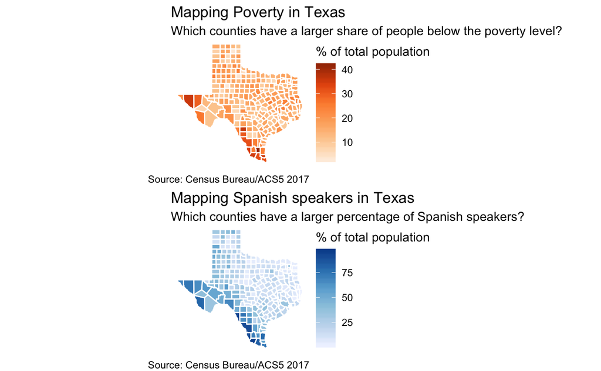

```r
poverty_map_gg <- ggplot(poverty_map) +
  geom_sf(aes(fill=pct_below), color="white") +
  theme_void() +
  theme(panel.grid.major = element_line(colour = 'transparent')) +
  scale_fill_distiller(palette="Oranges", direction=1, name="% of total population") +
  labs(title="Mapping Poverty in Texas", subtitle ="Which counties have a larger share of people below the poverty level?", caption="Source: Census Bureau/ACS5 2017")
spanish_map_gg <- ggplot(spanish_map) +
  geom_sf(aes(fill=spanish_pct), color="white") +
  theme_void() +
  theme(panel.grid.major = element_line(colour = 'transparent')) +
  scale_fill_distiller(palette="Blues", direction=1, name="% of total population") +
  labs(title="Mapping Spanish speakers in Texas", subtitle = "Which counties have a larger percentage of Spanish speakers?", caption="Source: Census Bureau/ACS5 2017")
iron(poverty_map_gg, spanish_map_gg)
```

From these two maps I found that both poverty and Spanish speakers have higher percentages in border communities. Maybe being a Spanish speaker doesn’t necessarily cause people to earn a lower income, but there has to be a relationship between the two.

Some more questions I have after these findings: * Are Spanish speakers “more likely to be in poverty” or are people below poverty level more likely to be Spanish speakers? Which is causing which? Or is there another factor that is causing the relationship?

To answer this question, I’ve looked at one more factor: educational attainment. I’ve also interviewed some people to understand this issue.

# Educational Attainment

Next, I want to compare the different language groups based on their educational attainment. The data I’m looking at breaks down groups speaking different languages at home based on their educational attainment and whether/not they’re in the labor force. For the purpose of this analysis, I’ll only look at educational attainment and not labor for participation.

I got this data from the census API. I imported and cleaned the data on a separate notebook (04_import_language_education.Rmd)

```r
language_by_education <- readRDS("data-out/language_by_education.rds")
```

To compare the language groups, I’m creating waffle charts again to compare between the language groups. This means I have to first save the data into different language groups before charting.

```r
spanish <- language_by_education %>%
  filter(language == "Speak Spanish") %>%
  select(language, education, employment, estimate, moe) #creating a table just for spanish
spanish_by_education <- spanish %>%
  group_by(education) %>%
  summarise(sum=sum(estimate)) #grouping by just eductaion because I'm not looking at labor force participation
spanish_by_education <- spanish_by_education %>%
  mutate(
    pct = sum / sum(sum) * 100
  )
spanish_pct <- spanish_by_education %>%
  mutate(sum = NULL) %>%
  spread(education, pct)
```

Doing the same thing for English

```r
english <- language_by_education %>%
  filter(language == "Speak only English")
english_by_education <- english %>%
  group_by(education) %>%
  summarise(sum=sum(estimate))
english_by_education <- english_by_education %>%
  mutate(
    pct = sum / sum(sum) * 100
  )
english_pct <- english_by_education %>%
  mutate(sum = NULL) %>%
  spread(education, pct) %>%
  select("Bachelor's degree or higher", "Some college or associate's degree", "High school graduate (includes equivalency)", "Less than high school graduate")
english_pct
```

| Bachelor's degree or higher | Some college or associate's degree | High school graduate (includes equivalency) | Less than high school graduate |
| --- | --- | --- | --- |
| 33.05408 | 33.38856 | 25.44511 | 8.112257 |

Doing the same thing for Asian & Pacific Island languages

```r
asian <- language_by_education %>%
  filter(language == "Speak Asian and Pacific Island languages")
asian_by_education <- asian %>%
  group_by(education) %>%
  summarise(sum=sum(estimate))
asian_by_education <- asian_by_education %>%
  mutate(
    pct = sum / sum(sum) * 100
  )
asian_pct <- asian_by_education %>%
  mutate(sum = NULL) %>%
  spread(education, pct) %>%
  select("Bachelor's degree or higher", "Some college or associate's degree", "High school graduate (includes equivalency)", "Less than high school graduate")
asian_pct
```

| Bachelor's degree or higher | Some college or associate's degree | High school graduate (includes equivalency) | Less than high school graduate |
| --- | --- | --- | --- |
| 52.69959 | 17.55938 | 15.50938 | 14.23166 |

Doing the same thing for Indo-European languages

```r
indoeuropean <- language_by_education %>%
  filter(language == "Speak other Indo-European languages")
indoeuropean_by_education <- indoeuropean %>%
  group_by(education) %>%
  summarise(sum=sum(estimate))
indoeuropean_by_education <- indoeuropean_by_education %>%
  mutate(
    pct = sum / sum(sum) * 100
  )
indoeuropean_pct <- indoeuropean_by_education %>%
  mutate(sum = NULL) %>%
  spread(education, pct) %>%
  select("Bachelor's degree or higher", "Some college or associate's degree", "High school graduate (includes equivalency)", "Less than high school graduate")
```

Doing the same thing for other languages

```r
other <- language_by_education %>%
  filter(language == "Speak other languages")
other_by_education <- other %>%
  group_by(education) %>%
  summarise(sum=sum(estimate))
other_by_education <- other_by_education %>%
  mutate(
    pct = sum / sum(sum) * 100
  )
other_pct <- other_by_education %>%
  mutate(sum = NULL) %>%
  spread(education, pct) %>%
  select("Bachelor's degree or higher", "Some college or associate's degree", "High school graduate (includes equivalency)", "Less than high school graduate")
```

Now, I will be creating separate charts and combining them with ggarrange.

```r
library(ggthemes)
library(ggplot2)
english_w <- waffle(english_pct, rows=3, colors = c("#ee4035", "#ffcc5c", "#7bc043", "#0392cf"), title = "English Only") + theme(legend.position = "none")
spanish_w <- waffle(spanish_pct, rows=3, colors = c("#ee4035", "#ffcc5c", "#7bc043", "#0392cf"), title ="Spanish") + theme(legend.position = "none")
indoeuropean_w <- waffle(indoeuropean_pct, rows=3, colors = c("#ee4035", "#ffcc5c", "#7bc043", "#0392cf"), title = "Other Indo-European languages") + theme(legend.position = "none")
asian_w <- waffle(asian_pct, rows=3, colors = c("#ee4035", "#ffcc5c", "#7bc043", "#0392cf"), title = "Asian & Pacific Island languages") + theme(legend.position = "none")
library(ggpubr)
combined_chart <- ggarrange(english_w, asian_w, indoeuropean_w, spanish_w, nrow = 4, common.legend = TRUE, legend ="right")
```

Adding titles to explain the chart

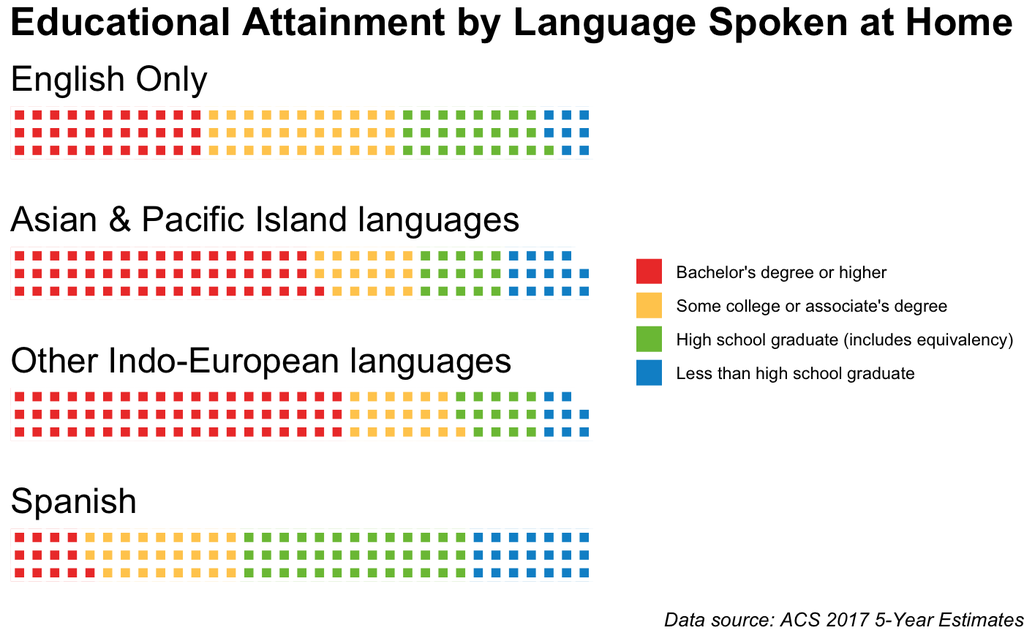

```r
annotate_figure(combined_chart,
               top = text_grob("Educational Attainment by Language Spoken at Home", color = "black", face = "bold", size = 20),
               bottom = text_grob("Data source: ACS 2017 5-Year Estimates", color = "black",
                                  hjust = 1, x = 1, face = "italic", size = 10))
```

Here you can see again that there’s a gap between education levels of other language speakers compared with Spanish speakers.

I’ve created a table also to look at the percentages.

```r
education_language_table <- bind_rows(
  "Speaks English Only" = english_pct,
  "Speaks Asian and Pacific Island Languages" = asian_pct,
  "Speaks Indo-european Languages" = indoeuropean_pct,
  "Speaks Spanish" = spanish_pct,
  "Speaks other languages" = other_pct,
  .id = "Language spoken at home")
education_language_table
```

| Language spoken at home | Bachelor's degree or higher | Some college or associate's degree | High school graduate (includes equivalency) | Less than high school graduate |
| --- | --- | --- | --- | --- |
| Speaks English Only | 33.05408 | 33.38856 | 25.44511 | 8.112257 |
| Speaks Asian and Pacific Island Languages | 52.69959 | 17.55938 | 15.50938 | 14.231658 |
| Speaks Indo-european Languages | 57.91457 | 19.40789 | 14.04012 | 8.637422 |
| Speaks Spanish | 13.02214 | 21.21475 | 26.38725 | 39.375854 |
| Speaks other languages | 46.48589 | 26.51643 | 17.64340 | 9.354286 |

A really small percentage of Spanish speakers have a Bachelor’s degree or higher, but a majority of those who speak Asian and Pacific Island languages hold a bachelor’s degree or higher. On the other hand, 39% of people who speak Spanish at home have less than a high school degree vs. only 14% of Asian & Pacific Island language speakers. I’ve interviewed ESL teachers from El Paso who have had experiences teaching Spanish speaking students as well as Asian language-speaking students, and they shared me their thoughts on why this gap exists.